# 0801CS171035_PROJECT2

## Morphological Feature Extraction of Image

Morphological image processing is a collection of operations related to the shape or morphology of features in an image, such as boundaries, skeletons, etc.We apply a structuring element to an input image and generate an output image.

### Structuring Element

we probe an image with a small shape or template called a structuring element, which defines the region of interest or neighborhood around a pixel.

```python
sys.path.insert(0,'E:\\7th sem all material\Morphological\Improved')
```

#### square(dim):

##### Parameter

dim: int

##### Return

2D- Array of 1's of specified dimension

```python
import numpy as np
import cv2 as cv
from matplotlib import pyplot as plt

#importing the  morphology implemented file
from Morphology import Morphology
```

```python
obj=Morphology()
```

```python
arr=obj.square(4)
arr
```

```
array([[1, 1, 1, 1],
       [1, 1, 1, 1],
       [1, 1, 1, 1],
       [1, 1, 1, 1]], dtype=uint8)
```

#### rectangle(col,row):

##### Parameter

col: int, breadth of rectangle row: int, length of rectangle

##### Return

2D- Array of 1's of specified dimension

```python
arr=obj.rectangle(3,4)
arr
```

```
array([[1, 1, 1, 1],
       [1, 1, 1, 1],
       [1, 1, 1, 1]], dtype=uint8)
```

### binary(img)

converts RGB image to binary image for further processing

##### Parameter

##### img

RGB

##### Return

binary image

[figure not shown]

```python
#Reading image
image=cv.imread(r'E:\7th sem all material\Morphological\Improved\flower.jpg')
plt.imshow(image, cmap='Greys_r')
```

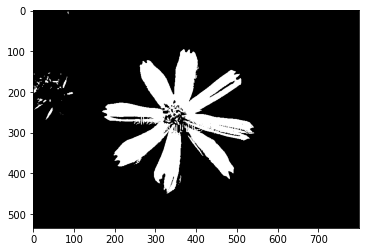

```python
image = obj.binary(image)
plt.imshow(image, cmap='Greys_r')
```

```python
#Dimension of binary image
print(image.ndim)
```

```
2
```

### Morphological Operation on Image

### Dilation

Dilation is a technique where we expand the image. It adds the number of pixels to the boundaries of objects in an image. The structuring element controls it.Dilation makes objects more visible and fills in small holes in objects.

### dilation(image,shape,*args)

##### Parameter:

#### img

input image

#### shape

structuring element('square' or 'rectangle')

#### *args:

it takes dimension values based on shape i.e.side length for square and length,breadth for rectangle

##### Return

Dilated Image

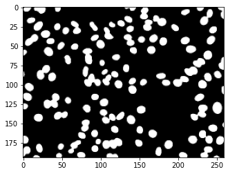

```python
# Image before dilation
image=cv.imread(r'E:\7th sem all material\Morphological\Improved\star.png')
plt.imshow(image, cmap='Greys_r')
```

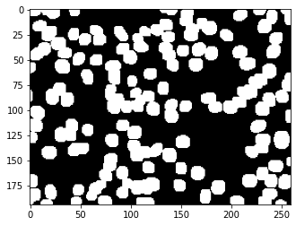

```python
#Reading image and applying dilation on it with structuring element of dimension 4*4

dil=cv.imread(r'E:\7th sem all material\Morphological\Improved\star.png')
dil=obj.dilation(dil,'square',4)
plt.imshow(dil, cmap='Greys_r')
```

### Erosion

Erosion erodes away the boundaries of objects. It is used to remove small white noises from the images. Erosion can also be used to detach two connected images.The thickness of object decreases.